# Assignment 3

```r
library(tseries)
library(zoo)
library(ggplot2)
library(forecast)
library(expsmooth)
library(fpp)
```

## Ch 8, Exercises 7, 9, 10, 11

### 7. Consider ‘wmurders’, the number of women murdered each year (per 100,000 standard population) in the United States.

#### a. By studying appropriate graphs of the series in R, find an appropriate ARIMA( p,d,q ) model for these data.

```r
autoplot(wmurders)
```

[output not shown]

```r
wmurders %>% ggtsdisplay()
```

[output not shown]

```r
wmurders %>% diff() %>% ggtsdisplay()
```

[output not shown]

```r
wmurders %>% diff() %>% diff() %>% ggtsdisplay()
```

[output not shown]

#### b. Should you include a constant in the model? Explain.

No.

#### c. Write this model in terms of the backshift operator.

# (1 - B)^2*yt = (1 + theta1*B + theta2*B^2)*et

#### d. Fit the model using R and examine the residuals. Is the model satisfactory?

```r
wm_model_1 <- Arima(wmurders,order=c(0,2,2))
summary(wm_model_1)
checkresiduals(wm_model_1)
```

[output not shown]

```r
wm_model_auto <- auto.arima(wmurders)
summary(wm_model_auto)
checkresiduals(wm_model_auto)
```

[output not shown]

#### e. Forecast three times ahead.

```r
wm_model_1 %>% forecast(h=3) %>% autoplot
```

[output not shown]

#### f. Create a plot of the series with forecasts and prediction intervals for the next three periods shown.

```r
wm_model_auto %>% forecast(h=3) %>% autoplot
```

[output not shown]

#### g. Does ‘auto.arima()’ give the same model you have chosen? If not, which model do you think is better?

### 9. For the ‘usgdp’ series:

#### a. if necessary, find a suitable Box-Cox transformation for the data;

```r
autoplot(usgdp)
lambda_gdp <- BoxCox.lambda(usgdp)
usgdp %>% BoxCox(lambda_gdp) %>% autoplot()
```

[output not shown]

#### b. fit a suitable ARIMA model to the transformed data using ‘auto.arima()’;

```r
auto_fit <- auto.arima(usgdp, lambda=lambda_gdp)
summary(auto_fit)
checkresiduals(auto_fit)
```

[output not shown]

```r
auto_fit2 <- auto.arima(usgdp, lambda=lambda_gdp, stepwise = FALSE, approximation = FALSE)
summary(auto_fit2)
checkresiduals(auto_fit2)
```

[output not shown]

#### c. try some other plausible models by experimenting with the orders chosen;

```r
arima_fit1 <- Arima(usgdp,order=c(1,1,0), lambda=lambda_gdp)
summary(arima_fit1)
checkresiduals(arima_fit1)
```

[output not shown]

```r
arima_fit2 <- Arima(usgdp,order=c(1,2,2), lambda=lambda_gdp)
summary(arima_fit2)
checkresiduals(arima_fit2)
```

[output not shown]

#### d. choose what you think is the best model and check the residual diagnostics;

#### e. produce forecasts of your fitted model. Do the forecasts look reasonable?

```r
arima_fit1 %>% forecast() %>% autoplot
```

[output not shown]

#### f. compare the results with what you would obtain using ‘ets()’ (with no transformation).

```r
ets_gdp <- ets(usgdp)
ets_gdp %>% forecast() %>% autoplot()
```

[output not shown]

### 10. Consider ‘austourists’, the quarterly number of international tourists to Australia for the period 1999-2010.

#### a. Describe the time plot.

```r
austourists %>% autoplot()
austourists %>% ggtsdisplay()
```

[output not shown]

#### d. Produce plots of the seasonally differenced data (1 - B^4)Yt. What model do these graphs suggest?

```r
adj_tour <- austourists %>% diff(lag=4)
ggtsdisplay(adj_tour)
```

[output not shown]

```r
arima_tour <- Arima(austourists,order = c(1, 1, 0),seasonal = c(1, 1, 0))
ggtsdisplay(arima_tour)
checkresiduals(arima_tour)
```

[output not shown]

#### e. Does ‘auto.arima()’ give the same model that you chose? If not, which model do you think is better?

```r
auto_tour <- auto.arima(adj_tour)
ggtsdisplay(auto_tour)
checkresiduals(auto_tour)
```

[output not shown]

#### f. Write the model in terms of the backshift operator, then without using the backshift operator.

```r
log_tour <- adj_tour %>% log()
fit_tour <- Arima(log_tour, order=c(2,1,0), seasonal=c(1,0,0))
summary(fit_tour)
checkresiduals(fit_tour)
```

[output not shown]

```r
fit_tour$model
```

[output not shown]

### 11. Consider ‘usmelec’, the total net generation of electricity (in billion kilowatt hours) by the U.S. electric industry (monthly for the period January 1973 - June 2013). In general there are two peaks per year: in mid-summer and mid-winter.

#### a. Examine the 12-month moving average of this series to see what kind of trend is involved.

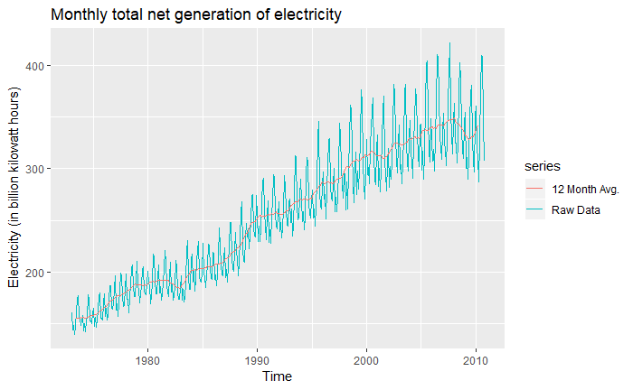

```r
meanelec  <- rollmean(usmelec,12)
autoplot(usmelec, series = "Raw Data") +
  autolayer(meanelec, series = "12 Month Avg.") +
  ylab(expression(paste("Electricity (in billion kilowatt hours)"))) +
  ggtitle("Monthly total net generation of electricity") #+
```

```r
  #scale_color_discrete(breaks = c("Raw Data", "12 Month Avg."))
```

#### b. Do the data need transforming? If so, find a suitable transformation.

```r
lambda_elec <- BoxCox.lambda(usmelec)
```

#### c. Are the data stationary? If not, find an appropriate differencing which yields stationary data.

The data is not stationary, so we need to difference it. Based on this, the data should probably be seasonally differenced, and potentially first difference it.

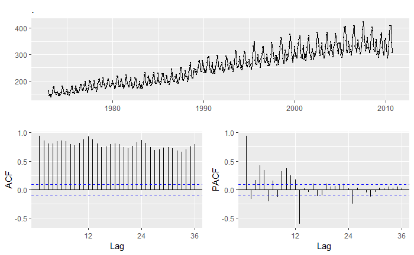

```r
usmelec %>% ggtsdisplay()
```

#### d. Identify a couple of ARIMA models that might be useful in describing the time series. Which of your models is the best according to their AIC values?

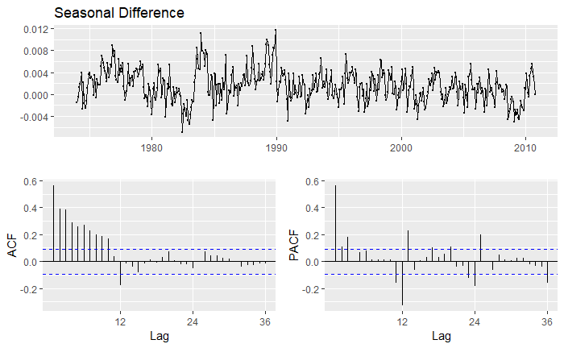

```r
usmelec %>% BoxCox(lambda_elec) %>% diff(lag=12)  %>% ggtsdisplay(main="Seasonal Difference")
```

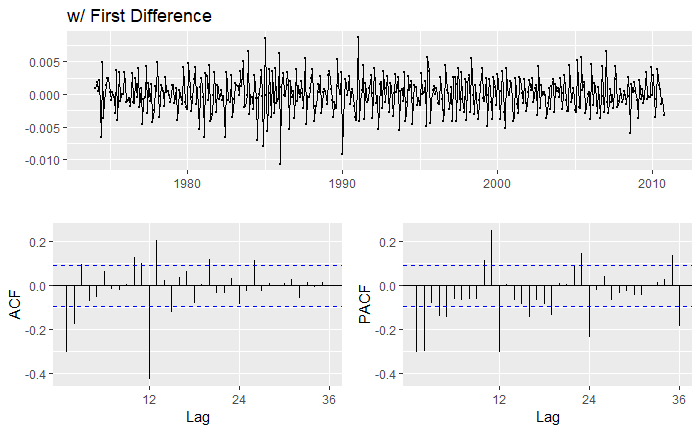

```r
usmelec %>% BoxCox(lambda_elec) %>% diff(lag=12)  %>% diff(lag=1) %>% ggtsdisplay(main="w/ First Difference")
```

```r
# I think that ARIMA(0, 1, 2)(0, 1, 1)[12] with Box-Cox transformation model might describe the data well. I'll try ARIMA(0, 1, 3)(0, 1, 1)[12] with Box-Cox transformation model, too.
usmelec_arima1 <- Arima(usmelec,order = c(0, 1, 2),seasonal = c(0, 1, 1),lambda = lambda_elec)
usmelec_arima2 <- Arima(usmelec,order = c(0, 1, 3),seasonal = c(0, 1, 1),lambda = lambda_elec)
summary(usmelec_arima1)
checkresiduals(usmelec_arima1)
summary(usmelec_arima2)
checkresiduals(usmelec_arima2)
# ARIMA(0, 1, 2)(0, 1, 1)[12] with Box-Cox transformation model was the best.
```

[output not shown]

#### e. Estimate the parameters of your best model and do diagnostic testing on the residuals. Do the residuals resemble white noise? If not, try to find another ARIMA model which fits better.

```r
usmelec_arima1
#theta1 = -0.4317, theta2 = -0.2552, phis1 = -0.8536
checkresiduals(usmelec_arima1)
# Ljung-Box test result shows that the residuals can be thought of as white noise. And they are normally distributed.
# I want to know what model was selected if I used auto.arima function. I'll try it.
usmelec_autoarima <- auto.arima(usmelec,lambda = lambda_elec)
usmelec_autoarima
# The result is ARIMA(2, 1, 4)(0, 0, 2)[12] with drift after Box-Cox transformation model. AIC is -4722. But I can't compare the AIC value with what I got above, because the number of differencing was different(Differencing changes the way the likelihood is computed).
checkresiduals(usmelec_autoarima)
# And the residuals aren't like white noise. Therefore I'll choose ARIMA(0, 1, 2)(0, 1, 1)[12] with Box-Cox transformation model.
```

[output not shown]

#### f. Forecast the next 15 years of electricity generation by the U.S. electric industry. Get the latest figures from the EIA to check the accuracy of your forecasts.

```r
fc_usmelec <- forecast(usmelec_arima1,h = 12*15)
# Get the latest figures.
#workdir <- "C:/Users/ca034330/Google Drive/Corey - School/!Fall 2018 B/BIA 6315 - Time Series and Forecasting/Assignment 3"
workdir <- "D:/Google Drive/Corey - School/!Fall 2018 B/BIA 6315 - Time Series and Forecasting/Assignment 3"
setwd(workdir)
usmelec.new <- read.csv("MER_T07_02A.csv", sep = ",")
# need to do data munging before using the data.
# make new columns Year, Month using YYYYMM column.
usmelec.new[, "Year"] <- as.numeric(substr(usmelec.new[, "YYYYMM"], 1, 4))
usmelec.new[, "Month"] <- as.numeric(substr(usmelec.new[, "YYYYMM"], 5, 6))
# make usmelec.new only have Year, Month and Value columns with net generation total data.
usmelec.new <- subset(usmelec.new, Description == "Electricity Net Generation Total, All Sectors", select = c("Year", "Month", "Value"))
# remove data if month is 13. They are old yearly data.
usmelec.new <- subset(usmelec.new, Month != 13)
# change the Value column data type to number. And divide the numbers by 1000 because the unit of the values in usmelec.new are Million KWh, not Billion KWh.
usmelec.new[, "Value"] <- as.numeric(as.character(usmelec.new[, "Value"]))/1000
# as.numeric(usmelec.new[, "Value"]) yields wrong data. Need to recognize the letters as character first, and then change the type as number.
head(usmelec.new)
tail(usmelec.new)
# first observation was taken in January, 1973. Final observation was taken in October, 2017.
# make ts time series using usmelec.new Value column data.
usmelec.new.ts <- ts(usmelec.new[, "Value"], start = c(1973, 1), frequency = 12)
tail(usmelec.new.ts)
# final observation was taken in October, 2017 as expected.
# get accuracy for 4 years of forecast horizon.
usmelec.new.ts_next4years <- subset(usmelec.new.ts, start = length(usmelec) + 1,end = length(usmelec) + 12*4)
accuracy(fc_usmelec_arima.0.1.2.0.1.1.12, usmelec.new.ts_next4years)
# plot the results
autoplot(fc_usmelec_arima.0.1.2.0.1.1.12, series = "Forecasts") + autolayer(usmelec.new.ts, series = "Real data") + scale_x_continuous(limits = c(2010, 2030)) + ggtitle("Forecast from ARIMA(0,1,2)(0,1,1)[12] with real data")
# Real data are really similar to the forecasts. Even when they were different, real data didn't get out of the prediction interval.
```

[output not shown]